# ch6_PythonExample

## 6.3b Tree-Based Regression Models in Python

This notebook is the Python counterpart of the R section **Tree-Based Regression Models in R**. The analysis is the same -- white-wine `quality`, single trees, cost-complexity pruning, random forests, and gradient boosting -- implemented with `scikit-learn`, `pandas`, and `matplotlib`.

`sklearn` does not reproduce `tree`, `rpart`, `randomForest`, or `gbm` line for line. Differences that change the output (a number or a plot) are discussed.

Two R packages fit trees in the notes: `tree` and `rpart`. In Python, we have one class, `DecisionTreeRegressor` that covers both illustration and pruning. Ensembles are `RandomForestRegressor` and `GradientBoostingRegressor`.

```python
import pandas as pd
import numpy as np
import matplotlib.pyplot as plt

from sklearn.model_selection import GridSearchCV, train_test_split
from sklearn.tree import DecisionTreeRegressor, plot_tree
from sklearn.ensemble import RandomForestRegressor, GradientBoostingRegressor
from sklearn.inspection import permutation_importance
from sklearn.metrics import mean_squared_error

plt.style.use("seaborn-v0_8-darkgrid")
RANDOM_STATE = 598  # same seed as the R notes
```

The `whitewines.csv` data set contains information on white variants of the Portuguese "Vinho Verde" wine.

The columns are: (a) `fixed acidity`, (b) `volatile acidity`, (c) `citric acid`, (d) `residual sugar`, (e) `chlorides`, (f) `free sulfur dioxide`, (g) `total sulfur dioxide`, (h) `density`, (i) `pH`, (j) `sulphates`, (k) `alcohol`, (l) `quality` (score between 0 and 10).

The file used here is the same semicolon-separated table as in the R notes and can be downloaded from there. The UCI page that contains a more detailed description is [Wine Quality](https://archive.ics.uci.edu/dataset/186/wine+quality).

```python
# sklearn wants valid Python identifiers, so we replace spaces with underscores.
whitewines = pd.read_csv("whitewines.csv", sep=";")
whitewines.columns = whitewines.columns.str.replace(" ", "_")

print("First 5 rows:")
display(whitewines.head())
print(f"\nDimensions (rows, columns): {whitewines.shape}")
```

```
First 5 rows:
```

|  | fixed_acidity | volatile_acidity | citric_acid | residual_sugar | chlorides | free_sulfur_dioxide | total_sulfur_dioxide | density | pH | sulphates | alcohol | quality |
| --- | --- | --- | --- | --- | --- | --- | --- | --- | --- | --- | --- | --- |
| 0 | 7.0 | 0.27 | 0.36 | 20.7 | 0.045 | 45.0 | 170.0 | 1.0010 | 3.00 | 0.45 | 8.8 | 6 |
| 1 | 6.3 | 0.30 | 0.34 | 1.6 | 0.049 | 14.0 | 132.0 | 0.9940 | 3.30 | 0.49 | 9.5 | 6 |
| 2 | 8.1 | 0.28 | 0.40 | 6.9 | 0.050 | 30.0 | 97.0 | 0.9951 | 3.26 | 0.44 | 10.1 | 6 |
| 3 | 7.2 | 0.23 | 0.32 | 8.5 | 0.058 | 47.0 | 186.0 | 0.9956 | 3.19 | 0.40 | 9.9 | 6 |
| 4 | 7.2 | 0.23 | 0.32 | 8.5 | 0.058 | 47.0 | 186.0 | 0.9956 | 3.19 | 0.40 | 9.9 | 6 |

```
Dimensions (rows, columns): (4898, 12)
```

### A Simple Regression Tree

In R the two-predictor illustration uses the `tree` package (`tree()`, `plot()`, `partition.tree()`). `sklearn`'s `DecisionTreeRegressor` is the analogue of both `tree` and `rpart`; there is no separate `partition.tree`.

The syntax is not a formula. We pass a design matrix `X` and a response vector `y`.

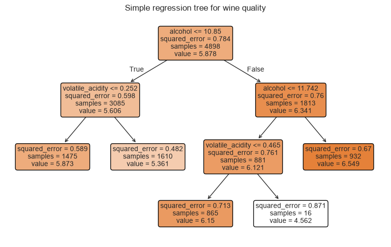

```python
# R: tree(quality ~ alcohol + volatile.acidity, data=whitewines)
feature_names = ["alcohol", "volatile_acidity"]
X_simple = whitewines[feature_names]
y = whitewines["quality"]

# sklearn grows until leaves are pure unless we stop it.
# tree() in R uses different defaults, so these two knobs are only
# to keep the illustration small and readable, not to match rpart's CP path.
simple_tree = DecisionTreeRegressor(
    max_depth=3,
    min_impurity_decrease=0.008,
    random_state=RANDOM_STATE,
)
simple_tree.fit(X_simple, y)

plt.figure(figsize=(10, 6))
plot_tree(
    simple_tree,
    feature_names=list(X_simple.columns),
    filled=True,
    rounded=True,
    fontsize=10,
)
plt.title("Simple regression tree for wine quality")
plt.show()
```

### Rectangular partition

R draws the partition with `partition.tree()`. `sklearn` has no helper, so the next cell is a small translation of the `tree` package geometry: walk the fitted tree and draw the cut segments in the (`alcohol`, `volatile_acidity`) plane.

Points are colored by `quality`, as in the R figure (not by the vertical coordinate).

```python
from matplotlib.collections import LineCollection


def _partition_segments(regressor, bbox, node=0):
    """Walk a two-predictor sklearn tree using child indices, not R's DFS vectors.

    bbox = [x_min, y_min, x_max, y_max]. Left child is {feature <= threshold}.
    """
    tree = regressor.tree_
    if tree.children_left[node] == -1:  # leaf
        return []

    feat = tree.feature[node]
    cut = tree.threshold[node]
    left = tree.children_left[node]
    right = tree.children_right[node]
    x_min, y_min, x_max, y_max = bbox
    segs = []

    if feat == 0:  # alcohol (x-axis)
        segs.append([(cut, y_min), (cut, y_max)])
        segs += _partition_segments(regressor, [x_min, y_min, cut, y_max], left)
        segs += _partition_segments(regressor, [cut, y_min, x_max, y_max], right)
    elif feat == 1:  # volatile_acidity (y-axis)
        segs.append([(x_min, cut), (x_max, cut)])
        segs += _partition_segments(regressor, [x_min, y_min, x_max, cut], left)
        segs += _partition_segments(regressor, [x_min, cut, x_max, y_max], right)
    else:
        raise ValueError("split on a variable other than the two plotted predictors")
    return segs


def partition_tree(regressor, data, y, ax=None, **scatter_kw):
    """Scatter two predictors and overlay the tree partition (R: partition.tree)."""
    x_min, y_min = data.min().to_numpy()
    x_max, y_max = data.max().to_numpy()
    pad_x = 0.025 * (x_max - x_min)
    pad_y = 0.025 * (y_max - y_min)
    bbox = [x_min - pad_x, y_min - pad_y, x_max + pad_x, y_max + pad_y]
    segs = _partition_segments(regressor, bbox)

    if ax is None:
        _, ax = plt.subplots()

    ax.scatter(data.iloc[:, 0], data.iloc[:, 1], c=y, **scatter_kw)
    ax.set_xlabel(data.columns[0])
    ax.set_ylabel(data.columns[1])
    ax.add_collection(LineCollection(segs, colors="k"))
    ax.autoscale()
    return ax
```

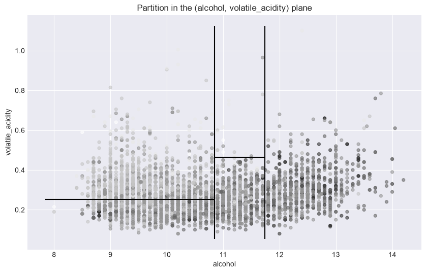

```python
fig, ax = plt.subplots(figsize=(10, 6))
partition_tree(simple_tree, X_simple, y, ax, cmap="Greys", alpha=0.6, s=18)
ax.set_title("Partition in the (alcohol, volatile_acidity) plane")
plt.show()
```

R also calls `prune.tree(..., best=4)` to force four leaves. The sklearn analogue is to pick a `ccp_alpha` (next section) or to set `max_leaf_nodes=4`. We skip that extra plot; the pruned full-predictor tree below is the one that corresponds to `prune()` in `rpart`.

### Fitting and Pruning a Regression Tree {-}

Unlike `rpart`, `sklearn` does **not** run cross-validation or prune while fitting. `DecisionTreeRegressor()` with default arguments grows a large tree $T_{\max}$ (the `cp = 0` fit `wine.tree2` in the notes). Pruning is a second step, using `ccp_alpha`.

`sklearn`'s `ccp_alpha` is $\alpha$ itself in $R_\alpha(T)=R(T)+\alpha|T|$. The *path* of trees is the same idea but the printed numbers are not on the same scale.

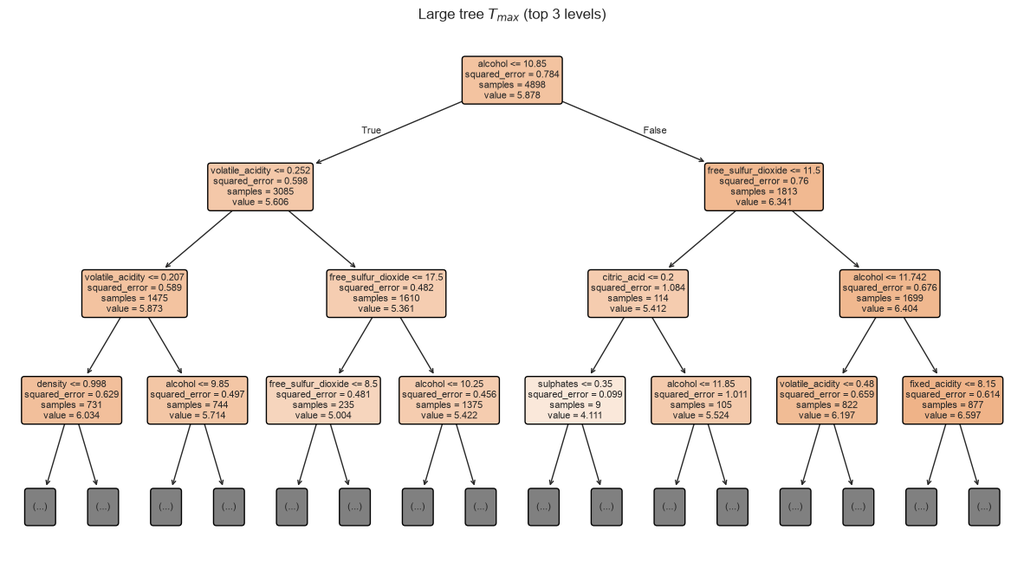

```python
X = whitewines.drop("quality", axis=1)
y = whitewines["quality"]

# Default sklearn tree = large T_max (R: control=list(cp=0)).
wine_tree_max = DecisionTreeRegressor(random_state=RANDOM_STATE)
wine_tree_max.fit(X, y)

# Full plot of T_max is unreadable; show the top layers only.
plt.figure(figsize=(15, 8))
plot_tree(
    wine_tree_max,
    max_depth=3,
    feature_names=list(X.columns),
    filled=True,
    rounded=True,
    fontsize=8,
)
plt.title("Large tree $T_{max}$ (top 3 levels)")
plt.show()
```

### Reading the Tree

Start at the root and read down. The root is the mean of `quality` over the whole sample. The first split is on `alcohol`. The left child is the lower-alcohol rows (lower mean); the right child is the rest. Leaves sit at the bottom; shading tracks the predicted mean. Exact means will match *this* fitted sklearn tree. The greedy search is the same idea, the tie-breaking and default stopping rules are not.

### Cross-validation and the $\alpha$ path

`rpart` builds the cost-complexity path and the CV table inside `rpart()`. In `sklearn` we ask for the path first, then run $K$-fold CV ourselves.

`cost_complexity_pruning_path` returns the increasing sequence of effective $\alpha$ values (the $\alpha_i$ from weakest-link pruning) and the corresponding total leaf impurity.

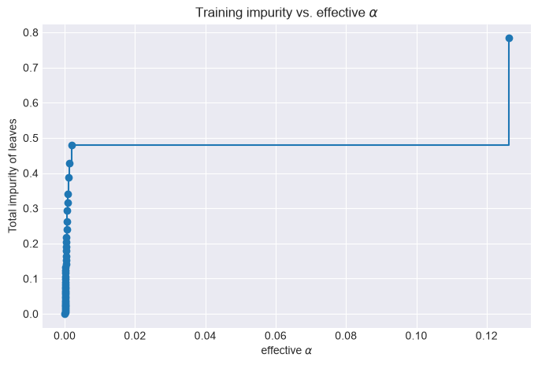

```python
path = wine_tree_max.cost_complexity_pruning_path(X, y)
# Full path can have hundreds of alphas (here often ~900).
# 10-fold CV on every value is too slow for a lecture notebook.
# Keep ~40 alphas spaced along the path, including the endpoints.
ccp_alphas_full, impurities_full = path.ccp_alphas, path.impurities
idx = np.unique(np.linspace(0, len(ccp_alphas_full) - 1, 40).astype(int))
ccp_alphas = ccp_alphas_full[idx]
impurities = impurities_full[idx]

plt.figure(figsize=(8, 5))
plt.plot(ccp_alphas, impurities, marker="o", drawstyle="steps-post")
plt.xlabel(r"effective $\alpha$")
plt.ylabel("Total impurity of leaves")
plt.title(r"Training impurity vs. effective $\alpha$")
plt.show()
```

### Choosing $\alpha$: minimum CV error and the 1-SE rule

As in the notes, use the *minimum cross-validation error* or the *one-standard-error (1-SE)* rule. We run 10-fold CV over the $\alpha$ path (`xval = 10` in `rpart.control`).

`GridSearchCV` reports mean *negative* MSE, so larger scores are better. The 1-SE tree is the *simplest* tree (largest $\alpha$) whose CV score is within one standard error of the best score.

```python
cv_fold = 10
tree_cv = GridSearchCV(
    DecisionTreeRegressor(random_state=RANDOM_STATE),
    param_grid={"ccp_alpha": ccp_alphas},
    cv=cv_fold,
    scoring="neg_mean_squared_error",
    n_jobs=-1,
)
tree_cv.fit(X, y)
```

```
GridSearchCV(cv=10, estimator=DecisionTreeRegressor(random_state=598),
             n_jobs=-1,
             param_grid={'ccp_alpha': array([0.00000000e+00, 9.42299840e-05, 9.81562333e-05, 1.02082483e-04,
       1.36109977e-04, 1.36109977e-04, 1.36109977e-04, 1.53123724e-04,
       1.53123724e-04, 1.63331972e-04, 1.67519972e-04, 1.72525365e-04,
       1.78644345e-04, 1.81479969e-04, 1.85604514e-04, 1.93917303e-04,
       2.04164965e-04, 2.15654769e-04, 2.33331389e-04, 2.44997958e-04,
       2.52952117e-04, 2.72219954e-04, 2.83562452e-04, 2.99041626e-04,
       3.11108519e-04, 3.35039943e-04, 3.53362440e-04, 3.75654051e-04,
       3.97070833e-04, 4.29721220e-04, 4.77469705e-04, 5.35933034e-04,
       6.06219171e-04, 6.76528453e-04, 7.65618620e-04, 8.86789095e-04,
       1.06515657e-03, 1.36815182e-03, 1.99701311e-03, 1.26260584e-01])},
             scoring='neg_mean_squared_error')
```

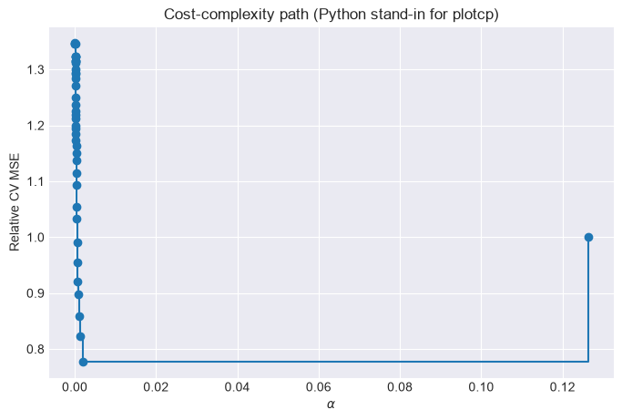

```python
# Relative CV error, analogous to rpart's xerror
# (divide by the CV error of the largest-alpha tree = the root).
cv_mse = -tree_cv.cv_results_["mean_test_score"]
cv_mse_rel = cv_mse / cv_mse[-1]

plt.figure(figsize=(8, 5))
plt.plot(ccp_alphas, cv_mse_rel, marker="o", drawstyle="steps-post")
plt.xlabel(r"$\alpha$")
plt.ylabel("Relative CV MSE")
plt.title("Cost-complexity path (Python stand-in for plotcp)")
plt.show()
```

```python
best_alpha = tree_cv.best_params_["ccp_alpha"]
best_idx = tree_cv.best_index_
best_score = tree_cv.best_score_  # negative MSE
print(f"alpha at minimum CV error: {best_alpha:.6f}")

# SE of the mean CV score. GridSearchCV's std_test_score is the
# standard deviation across folds; divide by sqrt(K) for the SE.
cv_scores = tree_cv.cv_results_["mean_test_score"]
best_se = tree_cv.cv_results_["std_test_score"][best_idx] / np.sqrt(cv_fold)
threshold = best_score - best_se

# ccp_alphas increase with simplicity. Take the last alpha still within 1 SE.
one_se_idx = np.where(cv_scores >= threshold)[0][-1]
one_se_alpha = ccp_alphas[one_se_idx]
print(f"1-SE alpha: {one_se_alpha:.6f}")
```

```
alpha at minimum CV error: 0.001997
1-SE alpha: 0.001997
```

[figure not shown]

```python
wine_tree_pruned = DecisionTreeRegressor(
    random_state=RANDOM_STATE, ccp_alpha=one_se_alpha
)
wine_tree_pruned.fit(X, y)

plt.figure(figsize=(10, 6))
plot_tree(
    wine_tree_pruned,
    feature_names=list(X.columns),
    filled=True,
    rounded=True,
    fontsize=8,
)
plt.title(rf"Pruned tree (1-SE $\alpha$ = {one_se_alpha:.4f})")
plt.show()
```

After the tree is fit, `predict()` produces fitted values on new or existing rows.

### Random Forests in Python

Load the forest estimator and hold out a test set. R used `sample()` with seed 598 and a 30% holdout. `train_test_split(..., random_state=598, test_size=0.3)` is the same *fraction* and the same seed integer, but it is **not** the same partition as R's `sample()`, so the MSEs will not match the knitted R output exactly.

```python
X_train, X_test, y_train, y_test = train_test_split(
    X, y, test_size=0.3, random_state=RANDOM_STATE
)
print(f"Train rows: {X_train.shape[0]}, test rows: {X_test.shape[0]}")
```

```
Train rows: 3428, test rows: 1470
```

### Model fitting

`RandomForestRegressor` is the analogue of `randomForest()`. Note that `oob_score_` itself is an OOB $R^2$, not an MSE. For a number comparable to the R notes we compute MSE from `oob_prediction_`.

```python
rf_wines = RandomForestRegressor(
    n_estimators=400,
    max_features=1 / 3,   # p/3, the usual regression default
    oob_score=True,
    random_state=RANDOM_STATE,
    n_jobs=-1,
)
rf_wines.fit(X_train, y_train)
print(f"max_features used: {rf_wines.max_features}")
print(f"mtry in the R notes was 3; here p/3 = {X_train.shape[1] / 3:.2f}")
```

```
max_features used: 0.3333333333333333
mtry in the R notes was 3; here p/3 = 3.67
```

Test-set mean squared error:

```python
test_mse = mean_squared_error(y_test, rf_wines.predict(X_test))
print(f"Test MSE: {test_mse:.4f}")
```

```
Test MSE: 0.3912
```

There are two training-side errors: the error of `predict()` on the training rows, and the out-of-bag error stored on the forest.

```python
train_mse = mean_squared_error(y_train, rf_wines.predict(X_train))
oob_mse = mean_squared_error(y_train, rf_wines.oob_prediction_)
print(f"Training MSE (in-sample predict): {train_mse:.4f}")
print(f"OOB MSE:                          {oob_mse:.4f}")
```

```
Training MSE (in-sample predict): 0.0498
OOB MSE:                          0.3700
```

The in-sample training error is much smaller than the test error. The OOB error is closer to the test error and is a more reliable estimate of generalization performance.

### Performance vs. Number of Trees

R's `plot(rf)` is OOB MSE against the number of trees. `sklearn` does not produce that plot. The next cell rebuilds a running OOB average from the individual trees. It uses `_generate_unsampled_indices`, an internal helper that mirrors how the forest drew each bootstrap sample. Treat it as a plotting device, not as public API.

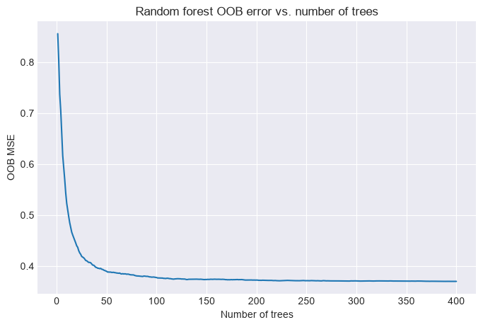

```python
from sklearn.ensemble._forest import _generate_unsampled_indices

n_samples = X_train.shape[0]
n_trees = rf_wines.n_estimators
oob_preds = np.full((n_samples, n_trees), np.nan)

for i, tree in enumerate(rf_wines.estimators_):
    oob_idx = _generate_unsampled_indices(tree.random_state, n_samples, n_samples, None)
    oob_preds[oob_idx, i] = tree.predict(X_train.iloc[oob_idx].to_numpy())

oob_count = np.cumsum(~np.isnan(oob_preds), axis=1)
with np.errstate(divide="ignore", invalid="ignore"):
    oob_mean = np.nancumsum(oob_preds, axis=1) / oob_count

oob_mse_path = np.nanmean((oob_mean - y_train.to_numpy()[:, None]) ** 2, axis=0)

plt.figure(figsize=(8, 5))
plt.plot(np.arange(1, n_trees + 1), oob_mse_path)
plt.xlabel("Number of trees")
plt.ylabel("OOB MSE")
plt.title("Random forest OOB error vs. number of trees")
plt.show()
```

The error usually drops quickly and then levels off. Extra trees rarely make the forest worse; they may simply be unnecessary.

### Variable Importance

R reports both `%IncMSE` (permutation) and `IncNodePurity` (RSS / impurity gain). `rf_wines.feature_importances_` is the impurity measure only. Permutation importance is computed separately with `permutation_importance` on the OOB-style held-out rows -- here we use the test set for a clean comparison.

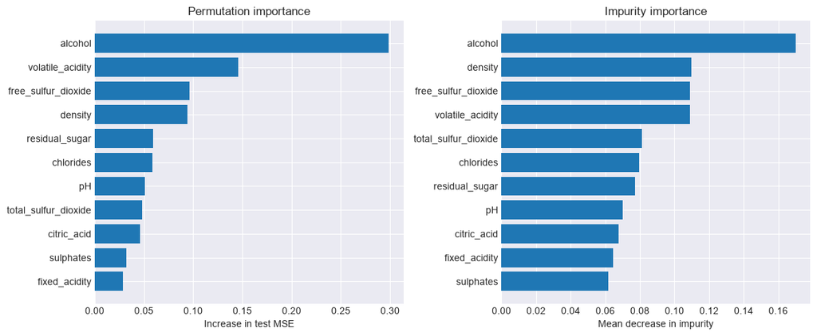

```python
impurity = pd.Series(rf_wines.feature_importances_, index=X.columns).sort_values()

perm = permutation_importance(
    rf_wines, X_test, y_test,
    n_repeats=10,
    random_state=RANDOM_STATE,
    n_jobs=-1,
)
perm_imp = pd.Series(perm.importances_mean, index=X.columns).sort_values()

fig, axes = plt.subplots(1, 2, figsize=(12, 5))
axes[0].barh(perm_imp.index, perm_imp.values)
axes[0].set_title("Permutation importance")
axes[0].set_xlabel("Increase in test MSE")
axes[1].barh(impurity.index, impurity.values)
axes[1].set_title("Impurity importance")
axes[1].set_xlabel("Mean decrease in impurity")
fig.tight_layout()
plt.show()
```

## Gradient Boosting Machines in Python

A GBM is a sum of trees built **sequentially**. For squared error, tree $t$ is fit to the current residuals and added with a learning rate $\lambda$:

$$ F_t(x) = F_{t-1}(x) + \lambda\,\hat h_t(x). $$

The `gbm` arguments and their sklearn names:

| sklearn (`GradientBoostingRegressor`) | Role |
| --- | --- |
| `loss="squared_error"` (default) | squared error |
| `n_estimators` | number of trees $T$ |
| `learning_rate` | $\lambda$ (default 0.1 in both) |
| `max_depth` | R default is 1 (stumps); sklearn default is 3 |
| `subsample` | R default 0.5; sklearn default 1.0 (no subsampling) |
| *none* | `gbm.perf` uses CV; sklearn has no built-in CV curve. We plot test MSE vs. $T$ with `staged_predict`. |

The first specification below uses no shrinkage and no subsampling, so it is close to unregularized stagewise fitting. That is a poor default; we use it only as a baseline, matching the R notes.

```python
gbm_wines = GradientBoostingRegressor(
    n_estimators=100,
    learning_rate=1.0,
    max_depth=3,
    subsample=1.0,
    random_state=RANDOM_STATE,
)
gbm_wines.fit(X_train, y_train)
```

```
GradientBoostingRegressor(learning_rate=1.0, random_state=598)
```

### Number of trees

`gbm.perf` picks $T$ from a CV curve. sklearn does not. `train_score_` is the *training* loss after each tree; `staged_predict` gives the test path. With $\lambda=1$, the test-MSE minimum is often early.

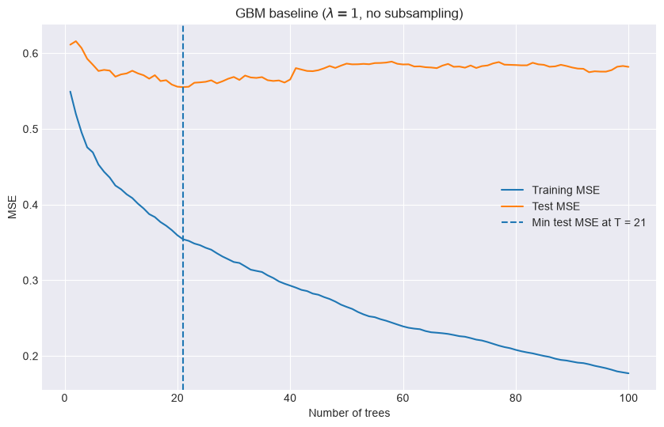

```python
train_err = gbm_wines.train_score_  # training MSE path
test_err = np.array([
    mean_squared_error(y_test, y_hat)
    for y_hat in gbm_wines.staged_predict(X_test)
])
opt_size = int(np.argmin(test_err) + 1)

plt.figure(figsize=(10, 6))
plt.plot(np.arange(1, len(train_err) + 1), train_err, label="Training MSE")
plt.plot(np.arange(1, len(test_err) + 1), test_err, label="Test MSE")
plt.axvline(opt_size, linestyle="--", label=f"Min test MSE at T = {opt_size}")
plt.xlabel("Number of trees")
plt.ylabel("MSE")
plt.title(r"GBM baseline ($\lambda = 1$, no subsampling)")
plt.legend()
plt.show()
```

A more standard specification: small learning rate, more trees, and `subsample=0.5` (`bag.fraction = 0.5`).

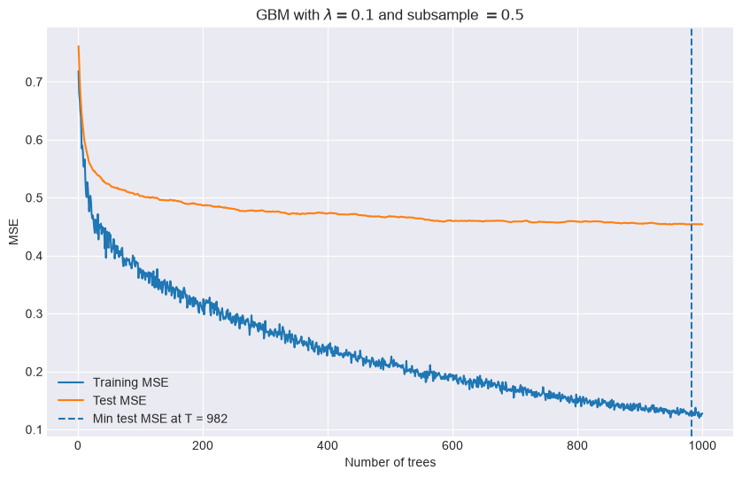

```python
gbm_wines2 = GradientBoostingRegressor(
    n_estimators=1000,
    learning_rate=0.1,
    max_depth=3,
    subsample=0.5,
    random_state=RANDOM_STATE,
)
gbm_wines2.fit(X_train, y_train)

train_err2 = gbm_wines2.train_score_
test_err2 = np.array([
    mean_squared_error(y_test, y_hat)
    for y_hat in gbm_wines2.staged_predict(X_test)
])
opt_size2 = int(np.argmin(test_err2) + 1)

plt.figure(figsize=(10, 6))
plt.plot(np.arange(1, len(train_err2) + 1), train_err2, label="Training MSE")
plt.plot(np.arange(1, len(test_err2) + 1), test_err2, label="Test MSE")
plt.axvline(opt_size2, linestyle="--", label=f"Min test MSE at T = {opt_size2}")
plt.xlabel("Number of trees")
plt.ylabel("MSE")
plt.title(r"GBM with $\lambda = 0.1$ and subsample $= 0.5$")
plt.legend()
plt.show()
```

### Variable Importance

`feature_importances_` on a GBM is the analogue of `gbm`'s relative influence (normalized total improvement from splits on that variable). A permutation measure is available as in the forest section; we plot both on the second, more standard fit.

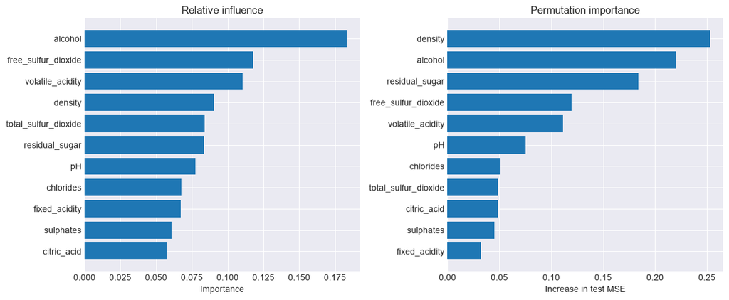

```python
rel_inf = pd.Series(gbm_wines2.feature_importances_, index=X.columns).sort_values()

perm_gbm = permutation_importance(
    gbm_wines2, X_test, y_test,
    n_repeats=10,
    random_state=RANDOM_STATE,
    n_jobs=-1,
)
perm_gbm_s = pd.Series(perm_gbm.importances_mean, index=X.columns).sort_values()

fig, axes = plt.subplots(1, 2, figsize=(12, 5))
axes[0].barh(rel_inf.index, rel_inf.values)
axes[0].set_title("Relative influence")
axes[0].set_xlabel("Importance")
axes[1].barh(perm_gbm_s.index, perm_gbm_s.values)
axes[1].set_title("Permutation importance")
axes[1].set_xlabel("Increase in test MSE")
fig.tight_layout()
plt.show()
```